# Long-term WQ: Sampling Effort

Dave Bosworth

June 27, 2022

# Purpose

Look at the sampling effort for the various WQ parameters to be included in the long-term WQ publication. Here are some notes and issues to consider:

Notable differences between `raw_chla_1975_2021` (from `DroughtData`) and the data used by the Primary Producers group:

1. `raw_chla_1975_2021` includes the four EZ stations from EMP
2. `raw_chla_1975_2021` has data for November 2021
3. `raw_chla_1975_2021` has additional Chlorophyll_Sign column that indicates whether the chlorophyll-a value is above or below the RL. For the 3 values that are below the RL, `raw_chla_1975_2021` reports them as equal to the RL, while the data from the Primary Producers group reports them as half the RL.

Things to consider with the nutrient, chlorophyll-a, and WQ data sets:

1. The chlorophyll-a data set includes the Grant Line Canal and Old River subregion. Should this region be included in the nutrient and WQ data sets?
2. The chlorophyll-a data set is not filtered to remove records where `Long_term == FALSE`, while those records are removed from the nutrient and WQ data sets. We may want to make these all consistent.

So far, these are the surveys included in this summary:

- **Water Temperature, Salinity, Secchi depth:** EMP, STN, FMWT
- **Nutrients:** EMP, USGS_SFBS, USGS_CAWSC (just 11447650 - Sacramento River at Freeport)
- **Chlorophyll-a:** EMP, USGS_SFBS

# Global code and functions

```r
# Load packages
library(tidyverse)
library(lubridate)
library(scales)
library(DroughtData)
library(discretewq)
```

# Import and Prepare Data

```r
# Define factor level for Region
region_lev <- c(
  "North",
  "SouthCentral",
  "Confluence",
  "Suisun Bay",
  "Suisun Marsh"
)

# Create a nested data frame and prepare to run the summary plot function on
ndf_lt_wq <-
  tibble(
    Parameter = c(
      "Temperature",
      "Salinity",
      "Secchi",
      "DissAmmonia",
      "DissNitrateNitrite",
      "DissOrthophos",
      "Chlorophyll"
    ),
    df_data = c(
      rep(list(raw_wq_1975_2021), 3),
      rep(list(raw_nutr_1975_2021), 3),
      list(raw_chla_1975_2021)
    )
  ) %>%
  mutate(
    df_data_c = map2(
      df_data,
      Parameter,
      ~ drop_na(.x, all_of(.y)) %>%
        mutate(
          Month = fct_rev(month(Date, label = TRUE)),
          Region = factor(Region, levels = region_lev)
        )
    )
  )
```

# Create Plots

```r
# Create function for sampling effort plots
plot_samp_effort <- function(df, grp_var, yr_var) {
  df %>%
    count(.data[[yr_var]], Month, .data[[grp_var]], name = "num_samples") %>%
    ggplot(aes(x = .data[[yr_var]], y = Month, fill = num_samples)) +
    geom_tile() +
    facet_grid(rows = vars(.data[[grp_var]]), drop = FALSE) +
    scale_x_continuous(breaks = breaks_pretty(20), expand = expansion()) +
    scale_y_discrete(drop = FALSE) +
    scale_fill_viridis_c(name = "Number of Samples") +
    theme_bw() +
    theme(
      axis.text.x = element_text(angle = 90, hjust = 1, vjust = 0.5),
      legend.position = "top"
    )
}
```

```r
# Create plots for each Parameter
ndf_lt_wq_plt <- ndf_lt_wq %>%
  mutate(plt = map(df_data_c, .f = plot_samp_effort, grp_var = "Region", yr_var = "YearAdj"))
```

# Sampling Effort

## Temperature

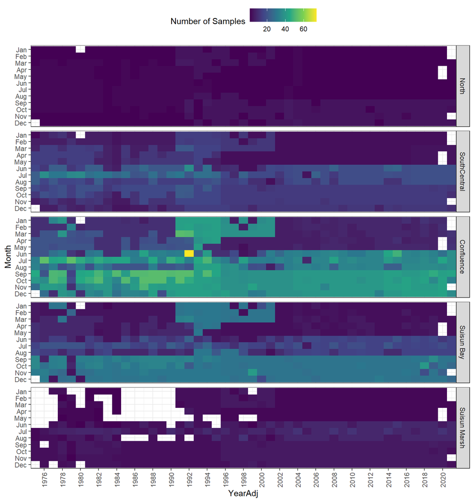

## Salinity

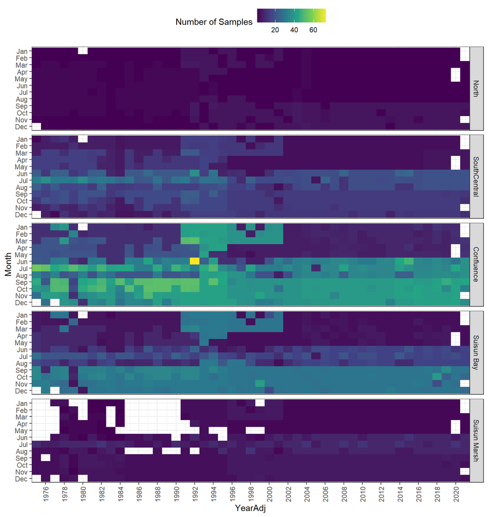

## Secchi

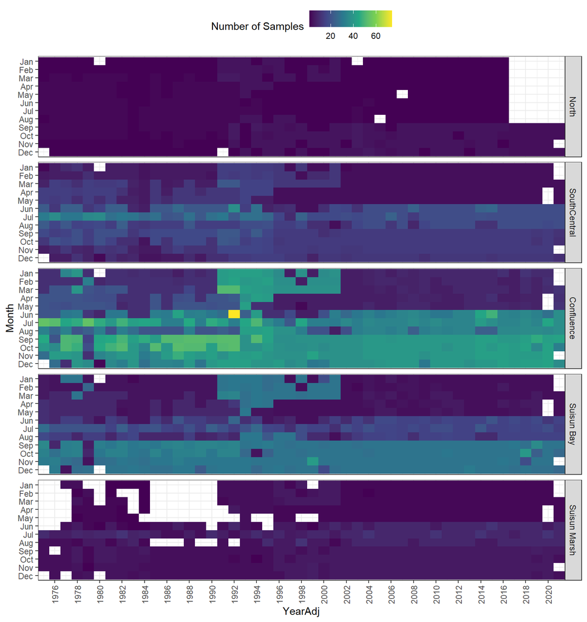

## DissAmmonia

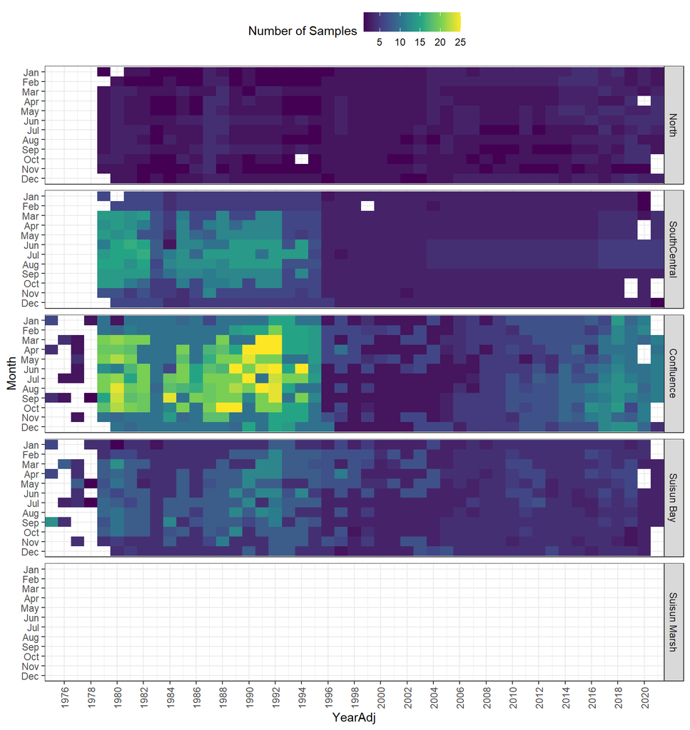

## DissNitrateNitrite

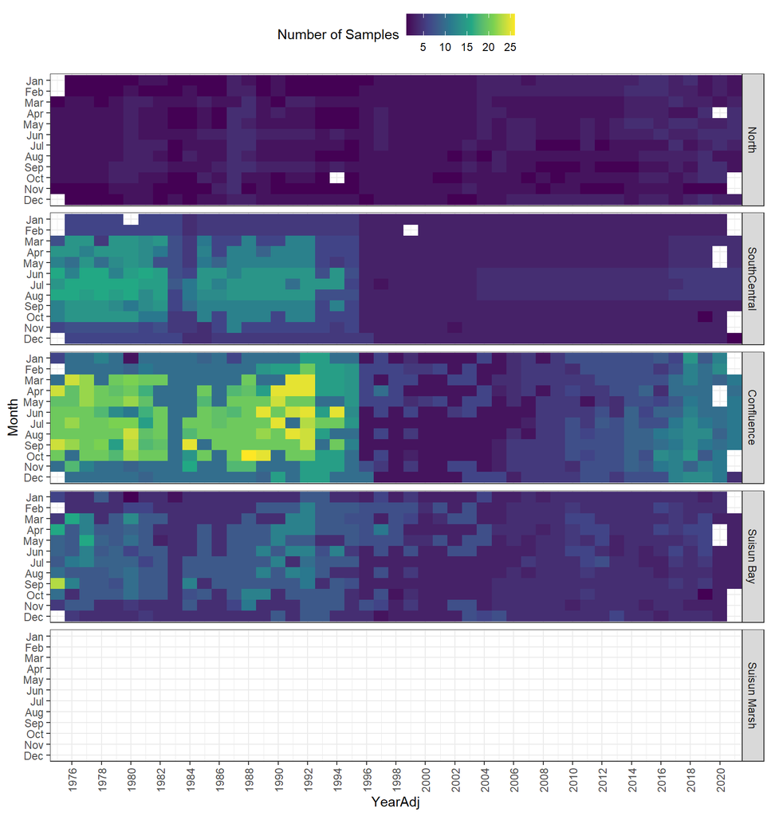

## DissOrthophos

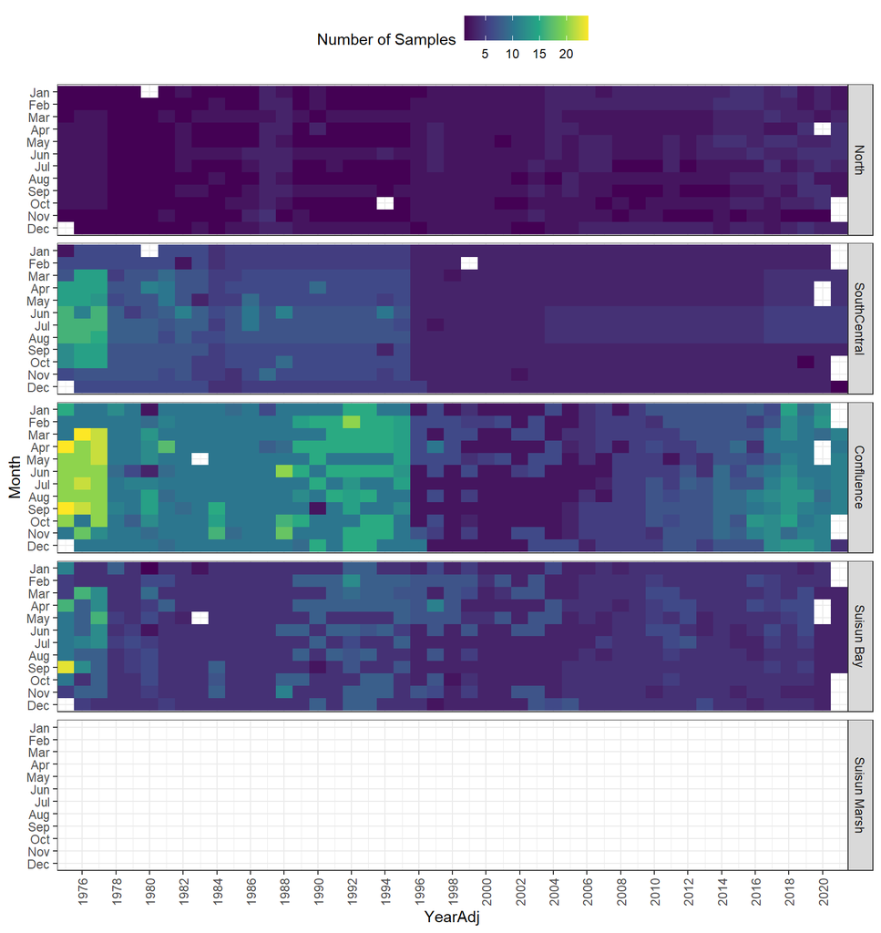

## Chlorophyll

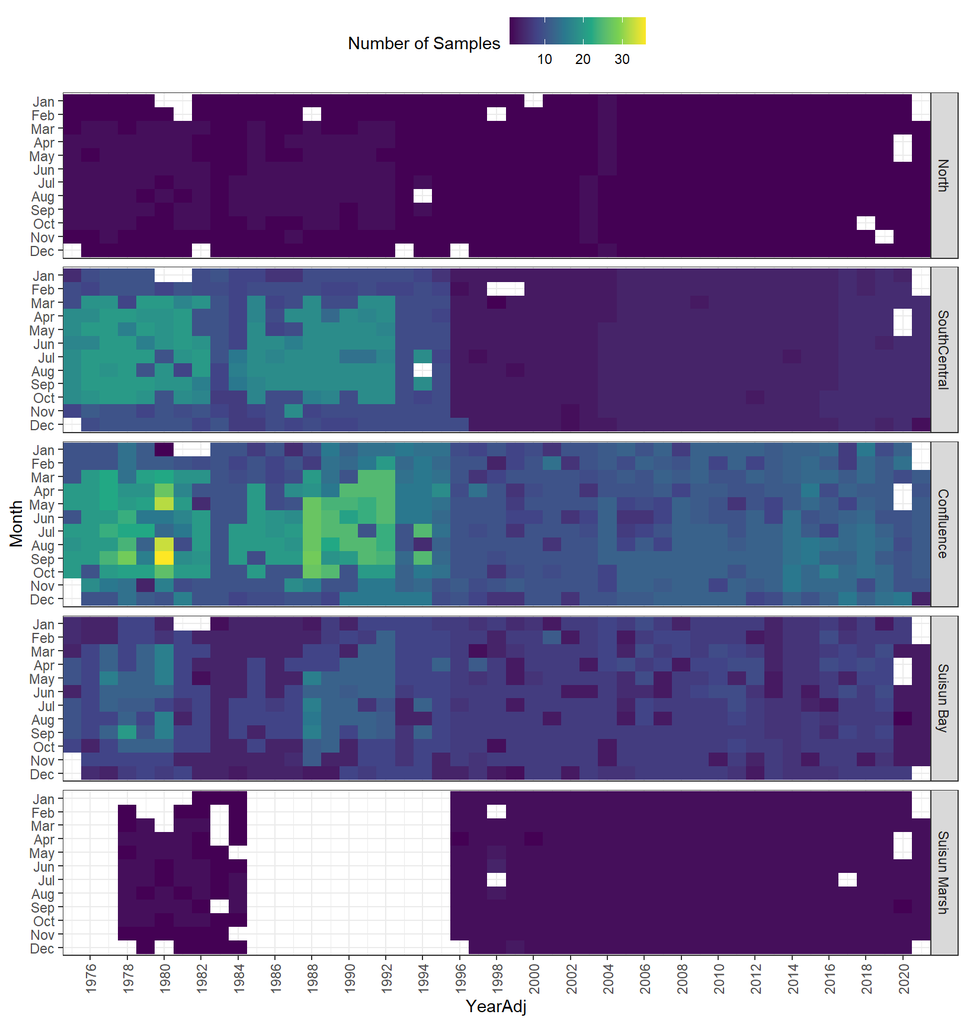

# Secchi Sampling Effort for North region

The secchi depth data has a large hole from Jan-Aug in 2017-2021 in the North region, which seems suspicious. Let’s look at the sampling effort for secchi for each station in the North region.

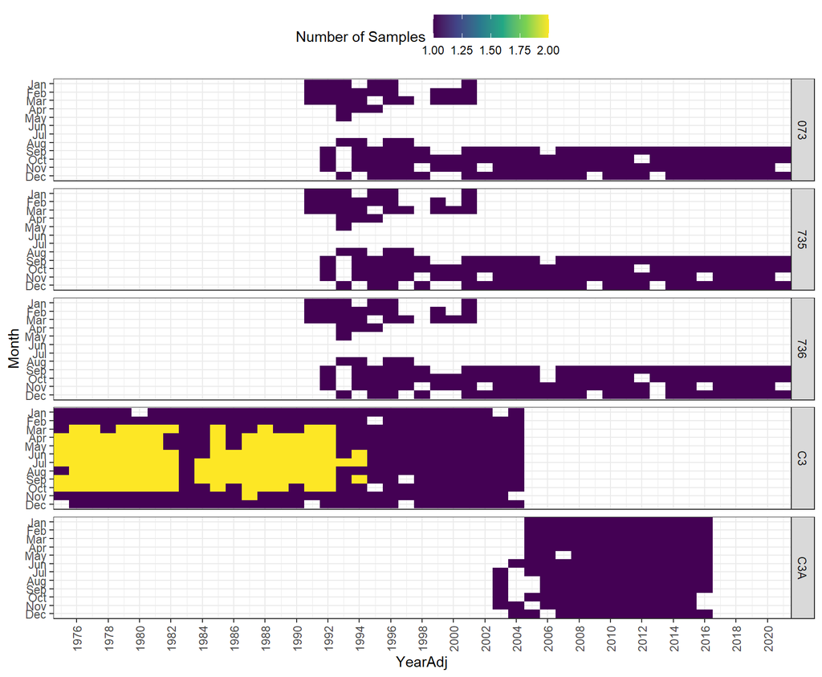

```r
ndf_lt_wq$df_data_c[[3]] %>%
  filter(Region == "North") %>%
  plot_samp_effort(grp_var = "Station", yr_var = "YearAdj")
```

Hmmm, the problem seems to be coming from the one current EMP station (C3A) in the North region. Let’s look at the data directly from the `discretewq` package (version 2.3.2) to see if other current EMP stations have WQ data during the same time period.

# WQ Sampling Effort for current EMP stations

```r
# Import EMP station metadata from most recent EDI publication to use for status designation
df_emp_meta <- read_csv("https://portal.edirepository.org/nis/dataviewer?packageid=edi.458.6&entityid=ecf241d54a8335a49f8dfc8813d75609")

# Create vector of stations with active status
emp_sta_active <- df_emp_meta %>%
  filter(Status == "Active") %>%
  pull(Station)

# Pull out water quality data from EMP dataset within discretewq
emp_wq <- discretewq::EMP %>%
  transmute(
    Station,
    Date = date(Date),
    Year = year(Date),
    Month = fct_rev(month(Date, label = TRUE)),
    Conductivity,
    Temperature,
    Secchi
  ) %>%
  # Only include active stations
  filter(Station %in% emp_sta_active)

# Create a nested data frame and run the summary plot function on each WQ parameter
ndf_emp_wq <-
  tibble(
    Parameter = c(
      "Conductivity",
      "Temperature",
      "Secchi"
    ),
    df_data = rep(list(emp_wq), 3)
  ) %>%
  mutate(
    df_data_c = map2(df_data, Parameter, ~ drop_na(.x, all_of(.y))),
    plt = map(df_data_c, .f = plot_samp_effort, grp_var = "Station", yr_var = "Year")
  )
```

It looks like only the shore-based stations (C3A, C10A, C9) have the issue of missing secchi depth data in recent years. Sarah Perry confirmed that EMP doesn’t collect secchi depth data at their shore-based stations anymore, so that explains what’s going on here.

## Conductivity

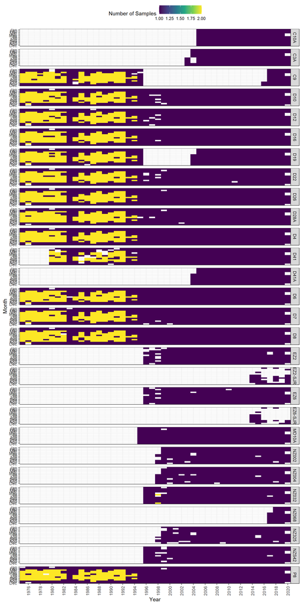

## Temperature

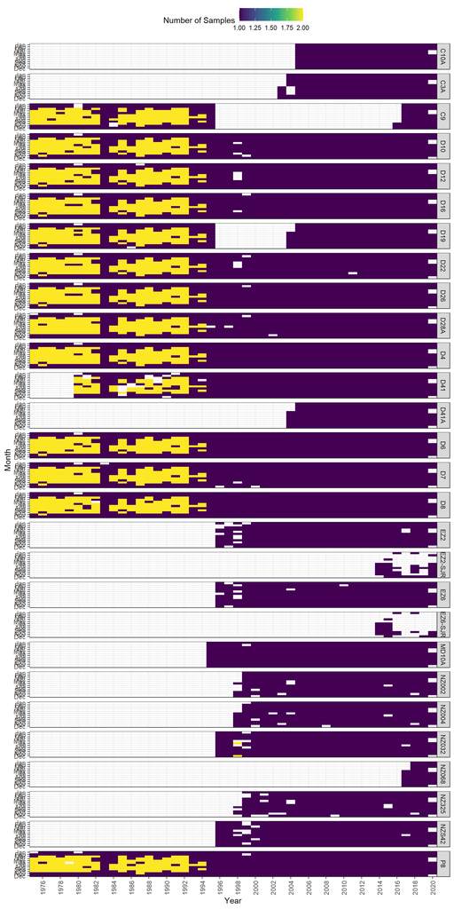

## Secchi

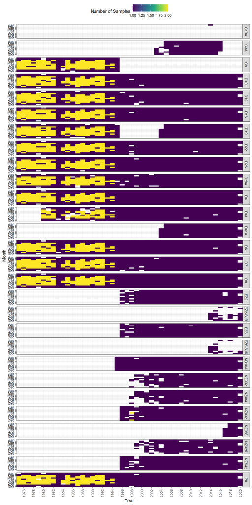